# 8 マッピング 3（衆院選・小選挙区）

Masahiko Asano

2025-11-25

- このセクションで使う `R パッケージ`一覧

```r
library(DT)
library(ggthemes)
library(jpndistrict)
library(magrittr)
library(remotes)
library(rnaturalearth)
library(rmarkdown)
library(sf)
library(tidyverse)
```

- 注意： `jpndistrict` パッケージ をインストールするときには、コンソールに次のコマンドを打ち込み、Enter key（もしくは Return key）を打つこと

```r
install.packages("devtools")
devtools::install_github("uribo/jpndistrict")
```

# 1. 衆院選挙区の地図を描く

- 2017年衆院選における静岡県（小選挙区）における立候補者の平均年齢を可視化する

## 1.1 衆院選選挙区マップデータを入手する

```r
df_dist_map <- st_read("shp/senkyoku289polygon.shp",
                       options = "ENCODING=CP932",
                       stringsAsFactors = FALSE) %>%
  rename(district = kuname)
```

```
options:        ENCODING=CP932
```

- 読み取った選挙区の地図データ (`df_dist_map`) の中身を確認

```r
head(df_dist_map) %>%
  rmarkdown::paged_table()
```

|  | kucode | district | ken | ku | geometry |
| --- | --- | --- | --- | --- | --- |
| 1 | 2809 | 兵庫9区 | 28 | 9 |  |
| 2 | 1303 | 東京3区 | 13 | 3 |  |
| 3 | 4010 | 福岡10区 | 40 | 10 |  |
| 4 | 4203 | 長崎3区 | 42 | 3 |  |
| 5 | 4703 | 沖縄3区 | 47 | 3 |  |
| 6 | 4701 | 沖縄1区 | 47 | 1 |  |

## 1.2 総選挙候補者年齢データの入手と加工

### 1.2.1 データの準備

・衆議院議員総選挙の得票データ hr96-24.csv をダウンロード  
- ダウンロードした `hr96-24.csv` を Rプロジェクトフォルダ内に作った `data` フォルダに入れる  
- データを読み込み `df_hr` と名前をつける

- `df_hr` には 22 個の変数が入っている

| 変数名 | 詳細 |
| --- | --- |
| year | 選挙年 (1996-2024) |
| pref | 都道府県名 |
| ku | 小選挙区名 |
| kun | 小選挙区 |
| rank | 当選順位 |
| wl | 選挙の当落: 1 = 小選挙区当選、2 = 復活当選、0 = 落選 |
| nocand | 立候補者数 |
| seito | 候補者の所属政党 |
| j_name | 候補者の氏名（日本語） |
| name | 候補者の氏名（ローマ字） |
| previous | これまでの当選回数（当該総選挙結果は含まない） |
| gender | 立候補者の性別: “male”, “female” |
| age | 立候補者の年齢 |
| exp | 立候補者が使った選挙費用（総務省届け出） |
| status | 候補者のステータス: 0 = 非現職、1 現職、2 = 元職 |
| vote | 得票数 |
| voteshare | 得票率 (%) |
| eligible | 小選挙区の有権者数 |
| turnout | 小選挙区の投票率 (%) |
| seshu_dummy | 世襲候補者ダミー: 1 = 世襲、0 = 非世襲（地盤世襲 or 非世襲） |
| jiban_seshu | 地盤の受け継ぎ元の政治家の氏名と関係 |
| nojiban_seshu | 世襲元の政治家の氏名と関係 |

- 必要な変数 (`year`, `ku`, `kun`, `age`) だけを抜き出す

```r
df_age <- df_hr %>%
  dplyr::select(year, ku, kun, age)
```

- 抜き出したデータフレーム `df_hr` を確認

```r
head(df_age)
```

```
# A tibble: 6 × 4
   year ku      kun   age
  <dbl> <chr> <dbl> <dbl>
1  1996 aichi     1    47
2  1996 aichi     1    72
3  1996 aichi     1    53
4  1996 aichi     1    43
5  1996 aichi     1    51
6  1996 aichi     1    51
```

### 1.2.2 データの加工（「選挙区」表記の統一）

- 前のセッションで入手した「地図データ」`df_dist_map` と ここで入手した「候補者年齢データ」`df_hr` は「選挙区」の値（表し方）が異なる

```r
head(df_dist_map)
```

```
Simple feature collection with 6 features and 4 fields
Geometry type: MULTIPOLYGON
Dimension:     XY
Bounding box:  xmin: 126.7099 ymin: 25.8132 xmax: 142.2371 ymax: 35.63099
CRS:           NA
  kucode district ken ku                       geometry
1   2809  兵庫9区  28  9 MULTIPOLYGON (((135.0025 34...
2   1303  東京3区  13  3 MULTIPOLYGON (((139.4133 34...
3   4010 福岡10区  40 10 MULTIPOLYGON (((131.0241 33...
4   4203  長崎3区  42  3 MULTIPOLYGON (((129.7689 33...
5   4703  沖縄3区  47  3 MULTIPOLYGON (((128.0207 27...
6   4701  沖縄1区  47  1 MULTIPOLYGON (((127.333 26....
```

|  | 変数名 | 値 |
| --- | --- | --- |
| 年齢データ (`df_age`) | ku, kun | aichi, 1 |
| マップデータ (`df_dist_map`) | kuname | 愛知1区 |

`df_age` → **漢字**と**数字**が分離（例えば「`aichi`」と「`1`」）  
`df_dist_map` → **漢字**と**数字**が混合（例えば「`愛知1区`」）

→ どちらかに統一する必要がある  
→ ここでは「年齢データ」の選挙区名を「`愛知1区`」のように変更  
→ `jpndistrict::jpnprefs`を使って日本語の都道府県名を取得する

```r
df_pref_name <- jpndistrict::jpnprefs %>%
    mutate(
        prefecture_en = str_remove_all(prefecture_en, c("-ken" = "",  #-kenを削除
                                                        "-to" = "",   #-to を削除
                                                        "-fu" = "")), #-fu を削除
        prefecture_en = str_to_lower(prefecture_en),
        prefecture = str_remove_all(prefecture, c("県" = "",  # 県を削除
                                                  "都" = "",  # 都を削除
                                                  "府" = "")) # 府を削除
    ) %>%
    select(prefecture, ku = prefecture_en) # 変数を 2 つに絞る
```

```r
head(df_pref_name)
```

```
# A tibble: 6 × 2
  prefecture ku
  <chr>      <chr>
1 北海道     hokkaido
2 青森       aomori
3 岩手       iwate
4 宮城       miyagi
5 秋田       akita
6 山形       yamagata
```

- `df_age`と`df_pref_name`をマージ → 日本語の選挙区名を作成
- 2017年のみをデータに絞る
- `df_hr17` と名前を付ける

```r
df_hr17 <- df_hr %>%
    left_join(df_pref_name, "ku") %>%
    filter(year == 2017) %>%
    mutate(
        district = str_c(prefecture, kun, "区")
    )
```

- `df_hr17` の変数を確認する

```r
names(df_hr17)
```

```
 [1] "year"          "pref"          "ku"            "kun"
 [5] "j_name"        "wl"            "rank"          "nocand"
 [9] "seito"         "...10"         "gender"        "name"
[13] "previous"      "age"           "exp"           "status"
[17] "vote"          "voteshare"     "eligible"      "turnout"
[21] "seshu_dummy"   "jiban_seshu"   "nojiban_seshu" "prefecture"
[25] "district"
```

- 必要な変数 (`district`, `age`) だけに絞る

```r
df_hr17 <- df_hr17 %>%
  select(district, age)
```

```r
head(df_hr17)
```

```
# A tibble: 6 × 2
  district   age
  <chr>    <dbl>
1 愛知1区     53
2 愛知1区     42
3 愛知1区     54
4 愛知2区     51
5 愛知2区     45
6 愛知2区     31
```

```r
df_hr17$age <- as.numeric(df_hr17$age)
```

- 2017年衆院選に出馬した候補者年齢の平均を選挙区毎に計算する

```r
df_hr17_age <- df_hr17 %>%
    group_by(district) %>%
    summarise(age_mean = mean(age, na.rm = T))
```

### 1.2.3 「選挙区マップ」と「候補者年齢データ」をマージ

- `df_dist_map`と`df_hr17_age`をマージする
- マージする前にそれぞれのデータを確認する

```r
head(df_hr17_age)
```

```
# A tibble: 6 × 2
  district age_mean
  <chr>       <dbl>
1 三重1区      57.5
2 三重2区      68
3 三重3区      51.2
4 三重4区      54.7
5 京1区        63
6 京2区        47.7
```

```r
head(df_dist_map)
```

```
Simple feature collection with 6 features and 4 fields
Geometry type: MULTIPOLYGON
Dimension:     XY
Bounding box:  xmin: 126.7099 ymin: 25.8132 xmax: 142.2371 ymax: 35.63099
CRS:           NA
  kucode district ken ku                       geometry
1   2809  兵庫9区  28  9 MULTIPOLYGON (((135.0025 34...
2   1303  東京3区  13  3 MULTIPOLYGON (((139.4133 34...
3   4010 福岡10区  40 10 MULTIPOLYGON (((131.0241 33...
4   4203  長崎3区  42  3 MULTIPOLYGON (((129.7689 33...
5   4703  沖縄3区  47  3 MULTIPOLYGON (((128.0207 27...
6   4701  沖縄1区  47  1 MULTIPOLYGON (((127.333 26....
```

- マージするデータフレーム (`df_hr17_age` と `df_dist_map`) を確認

```r
head(df_hr17_age)
```

```
# A tibble: 6 × 2
  district age_mean
  <chr>       <dbl>
1 三重1区      57.5
2 三重2区      68
3 三重3区      51.2
4 三重4区      54.7
5 京1区        63
6 京2区        47.7
```

```r
head(df_dist_map)%>%
  rmarkdown::paged_table()
```

|  | kucode | district | ken | ku | geometry |
| --- | --- | --- | --- | --- | --- |
| 1 | 2809 | 兵庫9区 | 28 | 9 |  |
| 2 | 1303 | 東京3区 | 13 | 3 |  |
| 3 | 4010 | 福岡10区 | 40 | 10 |  |
| 4 | 4203 | 長崎3区 | 42 | 3 |  |
| 5 | 4703 | 沖縄3区 | 47 | 3 |  |
| 6 | 4701 | 沖縄1区 | 47 | 1 |  |

- 両方のデータフレームに共通する変数 (`district`) を手がかりにしてマージする

```r
df_dist_map_age <- df_dist_map %>%
    left_join(df_hr17_age, by = "district") %>%
    st_as_sf()
```

- マージしたデータを確認

```r
DT::datatable(df_dist_map_age)
```

[output not shown]

[output cut: 280 more lines]

## 1.3 候補者の平均年齢の地図（静岡）

### 1.3.1 総選挙の選挙区マップ

- 静岡県のマップを表示させる
- チャンクオプションに {r map_dist_shizuoka_age, fig.height=10, fig.width=10} と指定

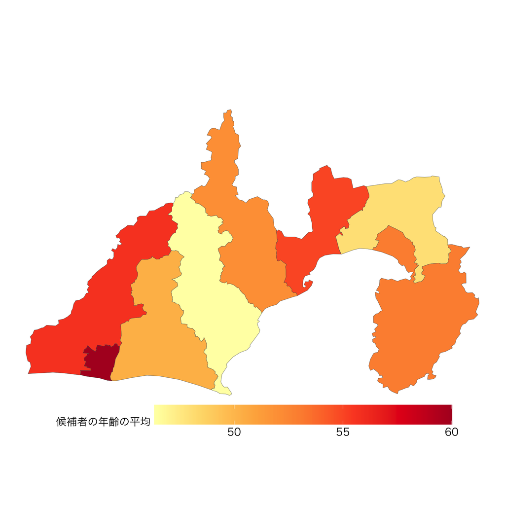

```r
map_dist_shizuoka_age <- df_dist_map_age %>%
    filter(str_detect(district, "静岡")) %>%
    ggplot() +
    geom_sf(aes(fill = age_mean)) +
    scale_fill_distiller(name = "候補者の年齢の平均",
                         palette = "YlOrRd", direction = 1) +
    theme_map(base_family = "HiraginoSans-W3") +
    theme(legend.position = c(.1, -.1),
          legend.direction = "horizontal",
          legend.title = element_text(size = 15),
          legend.text = element_text(size = 15),
          legend.key.size = unit(1, "cm"),
          legend.key.width = unit(3,"cm")) +
    coord_sf(datum = NA)

map_dist_shizuoka_age
```

- 作成したマップを `fig` に保存する
- 保存する前に予め Rプロジェクトフォルダに `fig` という名称のフォルダを作っておく

```r
ggsave("fig/map_dist_shizuoka_age.png", map_dist_shizuoka_age,
       width = 10, height = 10)
```

### 1.3.2 マップに衆院選挙区名を表示させる

- 地図に選挙区名を加えたい → `map_dbl`で座標の重心を設定

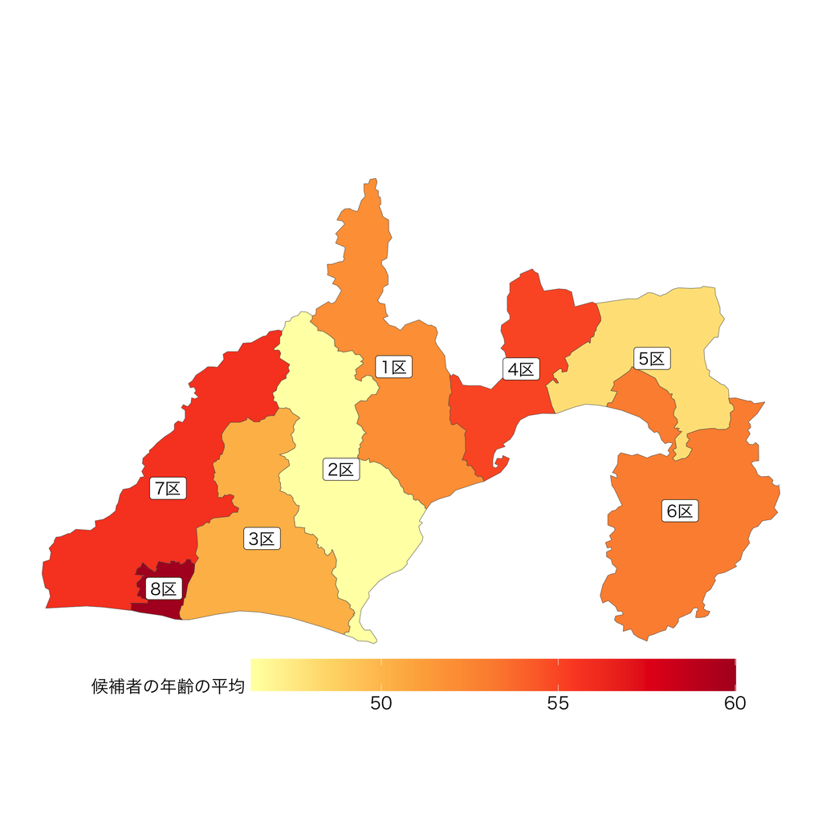

```r
map_dist_shizuoka_text <- df_dist_map_age %>%
    filter(str_detect(district, "静岡")) %>%
    mutate(
        text_x = map_dbl(geometry, ~st_centroid(.x)[[1]]),
        text_y = map_dbl(geometry, ~st_centroid(.x)[[2]]),
        district = str_remove_all(district, "静岡")
        ) %>%
    ggplot() +
    geom_sf(aes(fill = age_mean)) +
    geom_label(aes(x = text_x, y = text_y, label = district),
               size = 5, family = "HiraginoSans-W3") +
    scale_fill_distiller(name = "候補者の年齢の平均",
                         palette = "YlOrRd", direction = 1) +
    theme_map(base_family = "HiraginoSans-W3") +
    theme(legend.position = c(.1, -.1),
          legend.direction = "horizontal",
          legend.title = element_text(size = 15),
          legend.text = element_text(size = 15),
          legend.key.size = unit(1, "cm"),
          legend.key.width = unit(3,"cm")) +
    coord_sf(datum = NA)

map_dist_shizuoka_text
```

- 作成したマップを `fig` に保存する

```r
ggsave("fig/map_dist_shizuoka_text.png", map_dist_shizuoka_text,
       width = 10, height = 10)
```

### 1.3.3 Exercise

**Q1**: 「1.3.2. マップに衆院選挙区名を表示させる」の手法を参考にして、あなたが興味ある都道府県をひとつ選び、2017年総選挙における「立候補者数 (`nocand`) 」規模別のマップを描きなさい

**Q2**: 得られた結果からどのようなことが言えるか説明しなさい

**参考文献**

- [Claus O. Wilke, Fundamentals of Data Visualization](https://clauswilke.com/dataviz/?fbclid=IwAR1fjj7ejy6XNayFSFNKNMyc3ypCjkkAblzSkaR_RtRjdZ3stXCjoB6ious)
- 総選挙のマップ作成は遠藤勇哉氏（東北大学大学院情報科学研究科博士後期課程）の助言に基づいている
- [宋財泫 (Jaehyun Song)・矢内勇生 (Yuki Yanai)「私たちのR: ベストプラクティスの探究」](https://www.jaysong.net/RBook/)
- [土井翔平（北海道大学公共政策大学院）「Rで計量政治学入門」](https://shohei-doi.github.io/quant_polisci/data-import.html)
- [矢内勇生（高知工科大学）授業一覧](http://yukiyanai.github.io/teaching/)
- 浅野正彦, 矢内勇生.『Rによる計量政治学』オーム社、2018年
- 浅野正彦, 中村公亮.『初めてのRStudio』オーム社、2018年
- Winston Chang, R Graphics Cookbook, O’Reilly Media, 2012.
- Kieran Healy, DATA VISUALIZATION, Princeton, 2019
- Kosuke Imai, Quantitative Social Science: An Introduction, Princeton University Press, 2017